# Epidemiologische Modellierung als Reaktionsdiffusions-Prozess mit FDM

# Tutoriumsaufgabe 5c

### Implementation grundlegender Parameter

```matlab
% *** INPUT ***

%Raumvariablen
Rasterlaenge = 50; % Die interpolierte Matrix soll eine Rasterlaenge von "Rasterlaenge" in Metern haben. Entspricht h * 1000 Metern (h ist in km also 0,05 km)

% Zeitvariablen
Tage = 50;
delta_t = 0.05; %50 Zeiteinheiten entsprechen einem Tag
Zeitschritte = floor(Tage/delta_t); %Zeitschritte für alle Tage

%Plotten ja oder nein?
global plotten=true;
global speichern=false;

% Infektionsvariablen
BasisErkrankungsrate = 0.33; %"Rate der Infektionsverbreitung" bei einer Kontaktrate: Wahrscheinlichkeit des Kontakts eines Infizierten mit einem                                     Anfaelligen.
Wechselrate = (1/14); % von Infizierten zu Genesenen

% Diffussionskoeffizient
c_0 = 0.25/1000; % beschreibt Ausbreitungsgeschwindigkeit -> je größer, desto schneller verbreitet sich die Infektion im Raum durch Kontaktübertragung
                 %Basisdiffusionskoeffzient (gering waehlen, da bei BevDichte = 0 dieser Wert genommen wird)
```

### Bevölkerungdichtematrix

Bevökerungsdichte gibt an, wie viele Einwohner pro Flächeneinheit wohnen (hier entspricht ein Quadrat 1 km^2 ).

$ Bevölkerungsdichte(x)=\frac{Einwohneranzahl\ in\ Ort\ x}{Fläche\ des\ Ortes\ x}$

Da die Flächenheit hier 1km^2 ist, entspricht die Bevölkerungsdichte der absoluten Anzahl der Einwohner.

[figure not shown]

[Link zu den Daten](https://ec.europa.eu/eurostat/de/web/gisco/geodata/reference-data/population-distribution-demography/geostat)  
Die erste Zeile der Matrix entspricht der letzten Zeile des Bildes.

```matlab
function returnMatrix = BevDichteMatrix () %Matrix ist gedreht zum Bild aufgeschrieben, dass Bild später direkt mit Plott vergleichen kann
returnMatrix=[
              2084, 2746, 6583, 2137, 1518;
               561,  644, 4195, 3867, 2385;
              1197, 1001, 1543,  636, 2203;];
endfunction
```

### Interpolation & Extrapolation der Bevölkerungsmatrix

Einlesen der Bevölkerungsverteilung in Landau und anschließende Interpolation und Extrapolation eben jener.

Interpolation: Schätzung eines Wertes innerhalb zweier bekannter Werte -> zu gegebenen diskreten Daten soll eine stetige Funktion gefunden werden  
(Animation siehe https://de.wikiversity.org/wiki/Konvexkombination, Autor: Prof. Niehaus)  
Extrapolation: Schätzung eines Wertes; Schätzung basiert auf Erweiterung bekannter Werte und geht über bekannten Bereich hinaus

Ziel dieser Berechnungen ist es, den Wert der Bevölkerung wie im Bild anzugeben und auf die Mittelpunkte der Quadrate zu legen.

```matlab
function [IntBevMatrix, M, N, h] = InterpoliereBevDichteMatrix (BevMatrix,RasterlaengeInMetern)

 m = rows(BevMatrix);
 n = columns(BevMatrix);

 h = RasterlaengeInMetern/1000; %Schrittweite in km.
 AnzahlPunkteProKilometer = floor(1/h);

 M = m * AnzahlPunkteProKilometer; %Anzahl der Punkte in y-Richtung (Spalte)
 N = n * AnzahlPunkteProKilometer; %Anzahl der Punkte in x-Richtung (Zeile)


 hilfsM = M-AnzahlPunkteProKilometer; %Anzahl der "inneren Punkte" in y-Richtung (Spalte)
 hilfsN = N-AnzahlPunkteProKilometer; %Anzahl der "inneren Punkte" in x-Richtung (Spalte)

 %Verschiebung der Punkte in Mitte der Quadrate
 x = 0.5:1:n-0.5;
 y = 0.5:1:m-0.5;

 %Interpolation
 xi = linspace (min (x), max (x), hilfsN); %unterteilt den "Raum" vom Anfangswert min(x) bis Endwert max(x) in hilfsN gleich große Schritte
 yi = linspace (min (y), max (y), hilfsM)';% hier zusätzlich transponiert -> macht aus Zeilenvektor -> Spaltenvektor

 hilfsBevMatrix = interp2 (x,y,BevMatrix,xi,yi,"cubic"); %übergibt ursprungs x,y, z-Koordinate(BevMatrix) sowie neuen xi,yi zur Interpolation
                                                         %-> erhält interpolierte zi-Kooridnaten (hilfsBevMatrix)
                                                         %Interpolation kubisch -> verläuft als Linien
 %Extrapolation
 xxi = linspace (min (x)-0.5, max (x)+0.5, N); %betrachtet gesamtes Gebiet mit N gleich großen Unterteilungen
 yyi = linspace (min (y)-0.5, max (y)+0.5, M)';

 IntBevMatrix = griddata(xi,yi,hilfsBevMatrix,xxi,yyi,"nearest"); %extrapoliert die ganze Matrix
                                                                  %da Werte außerhalb Punkte nicht bekannt muss extrapolieren, da Punkte in Mitte der                                                                     Quadrate liegen
                                                                  %nearest-> nearest neighbour interpolation

 %Normieren, damit nicht mehr Einwohner entstehen

 %Gesamtpersonenanzahl der urprünglichen BevMatrix von Landau
 sollMenschen = sum(sum(BevMatrix))*1^2; % 1^2 da die Flaeche ein Kilometer^2 ist (absolute Personenanzahl=Bevdichte*Fläche -> siehe Formel)
                                         %"sum" summiert Spalten -> will Gesamtanzahl deswegen zweimal sum
 %Gesamtpersonenanzahl der interpolierten BevMatrix
 istMenschen = sum(sum(IntBevMatrix))*h^2; %Dichtefunktion - auf die Fläche bringen --> Bevölkerung
 quotient= sollMenschen/istMenschen;
 %erhählt urprüngliche Gesamtpersonenanzahl für interpolierte Matrix
 IntBevMatrix = quotient*IntBevMatrix;

%Plotten der interpolierten Matrix
global plotten;
global speichern;

if plotten==true
   figure(9990) %jeder Plot den man macht wird in einer Figur gespeichter und mit figure() gibt Figur einen Namen
   surface (xxi,yyi,IntBevMatrix); %stellt di Oberfläche der interpolierten -Gesamtmatrix dar
   axis([min(min(x(:)),min(y(:))) max(max(x(:)),max(y(:))) min(min(x(:)),min(y(:))) max(max(x(:)),max(y(:)))])
   [x,y] = meshgrid (x,y); %erzeugt Gitter (2Matrizen), die die Position der einzelnen Koordinaten wiedergeben
   hold on;
   plot3 (x,y,BevMatrix,"ro"); %plotter ursprünglichen Werte der Bevmatrix, um zu überprüfen, ob Interpolation gut ist
                               %Plot hier in CoCalc auf Bild nicht sichtbar -> wären rote Kreise der Werte zu sehen
   title ("Bevoelkerungsdichte Landau");
   ylabel("y")
   xlabel("x")
   colorbar %zeigt an, welche Werte den Farben zugeordnet werden
   hold off;

if speichern==true
      filename=["Images/Bevoelkerungsdichte.jpg"];
      saveas(9990, filename)
      %close (9990)
    endif
 endif
endfunction
```

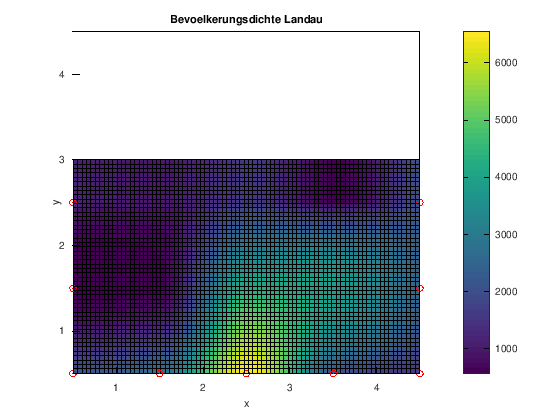

```matlab
% *** Bevoelkerungsmatrix ***
B = BevDichteMatrix();
[B_Interpoliert, M, N, h] = InterpoliereBevDichteMatrix(B, Rasterlaenge);

global x = linspace(0,N*h,N);
global y = linspace(0,M*h,M);
```

absolute Anzahl der Personen pro Gitterfläche berechnet sich z.B. $6000*h^2 = 6000* 0.05*0.05= 15$ Menschen pro Gitterfläche

## Ortsabhaengige Diffusionskoeffizientenmatrix

Definition einer Matrix, welche die Diffusion abhängig von der Bevölkerung beschreibt.  
Wahl fiel hier auf die lineare Diffusionskoeffizientenmatrix.

- Je höher die BevDichte, desto höher der Diffusionskoeffizient.
- Daraus folgt, dass bei hohen BevDichte die Infektion sich schneller verbreitet als bei einer niedrigen BevDichte.

[figure not shown]

  orange: linearer Diffusionskoeffizient  
  blau: nichtlinearer Diffusionskoeffizient

```matlab
function C = LineareDiffusionskoeffizientMatrix (B, c_0, a)
  C = c_0 .+ a.*B;
  %C(B<=0)=0; %Verbreitung 0 falls keine BevDichte an dieser Stelle
global plotte;
if(plotte)
   figure(9991)
   global x;
   global y;
   surface (x,y,C, "EdgeColor", "none");
   title (["Lineare Diffusionskoeffizient Matrix c_0 = " num2str(c_0) "   a = " num2str(a)]);
     axis([min(min(x),min(y)) max(max(x),max(y)) min(min(x),min(y)) max(max(x),max(y))])
   ylabel("y")
   xlabel("x")
   colorbar
endif

endfunction
```

```matlab
% *** Ortsabhaengige Diffusionskoeffizientenmatrix ***
BasisKoeffizientFaktor = 50;
a = ((BasisKoeffizientFaktor-1)*c_0)*(1/max(B_Interpoliert(:))); %-1, dass 50fache hat und nicht 51fache, da C=c_0+a*B -> hier kommt ein c_0 dazu
% Der Diffusionskoeffizient ist an der Stelle mit der hoechsten BevDichte, "BasisKoeffizientFaktor" mal so hoch wie der Basisdiffusionskoeffizient
C_Linear = LineareDiffusionskoeffizientMatrix(B_Interpoliert,c_0, a);
```

## Systemmatrix für ortsabhängigen Diffusionskoeffizienten

### Finite-Differenzen-Methode

- numerisches Verfahren zur Lösung von Differentialgleichungen
- Basis: Gitter mit endlich vielen (finiten) äquidistanten Gitterpunkten
- Idee: approximiert unbekannte Dichtefunktion u(x,t) mithilfe des Differenzenquotient

aus der Taylorentwicklung und der Vorraussetzung, dass f hinreichend oft differenzierbar ist ergibt sich:

- für den ersten **(vorwärts-) Differenzenquotienten**  
  $ D^+_h f(x):= \frac{f(x+h)-f(x)}{h}$
- für den ersten **(rückwärts-) Differenzenquotienten**  
  $ D^-_h f(x):= \frac{f(x)-f(x-h)}{h}$

da für Reaktionsdiffusionsgleichung 2. partielle Ableitung braucht, braucht **zweiten Differenzenquotient**:

- $ D^2f(x)\approx f''(x) $
- $D^2_h f(x):=\frac{f(x+h)-2f(x)+f(x-h)}{h^2}$
- Herleitung: Differenz von vorwärts- und rückwärts Differenzenquotient und Teilen durch h

##### **Sternschema** - FDM in 2D

braucht zweiten Differenzenquotient in x- und y- Richtung:

- $\frac{\partial ^2 u(x_i,y_j) }{\partial x^2} \approx D^2_{h,x} u(x_i,y_j):=\frac{u(x_{i+1},y_j)-2u(x_i,y_j)+u(x_{i-1},y_j)}{h^2}=\frac{u_{i+1, j}-2u_{i, j}+u_{i-1, j}}{h^2}$,
- $ \frac{\partial ^2 u(x_i,y_j) }{\partial y^2} \approx D^2_{h,y} u(x_i,y_j):=\frac{u(x_i,y_{j+1})-2u(x_i,y_j)+u(x_i,y_{j-1})}{h^2}=\frac{u_{i, j+1}-2u_{i, j}+u_{i, j-1}}{h^2}$

durch Addition erhält Approximationsschema -> Sternschema

- **$\Delta u(x_i,y_j) \approx \frac{u_{i+1, j}+u_{i, j+1}-4u_{i, j}+u_{i-1, j}+u_{i, j-1}}{h^2}, \qquad i=1,\ldots n,\ j=1, \ldots m.$**

[figure not shown]

### Instationäres homogenes Neumann Randwertproblem

$\quad \partial_t u(x,t)-div\ (c(x)\nabla u(x,t))=f(u(x,t)),\ \ x \in \ D\subset \mathbb{R}^2, \ t \in (t_0,T),$

$\quad \frac{\partial u(x)}{\partial \vec{n}}\equiv \nabla u \cdot \vec{n}=0 \quad x \in \partial D$

Richtungsableitung der Funktion u in Richtung des äußeren Normalenvektors gegeben

#### Homogene Neumann Randbedingung

$c*\nabla u \cdot \vec{n}=0$

1. **linker & rechter Rand** : x-Ableitung $\quad c* \partial_x u \cdot \vec{n_1}=0$

[figure not shown]

In den Randpunkten wird nicht das Sternschema angewendet, sondern der einseitige Differenzenquotient

- linker Rand: den vorwärts -Differenzenquotient $D^+_{h,x} u(x_0,y_j)=\frac{u_{1,j}-u_{0,j}}{h}\approx \frac{\partial u}{\partial x}(x_0, y_j)) \equiv 0$
- rechter Rand: den rückwärts -Differenzenquotient $ D^-_{h,x} u(x_{n+1},y_j)=\frac{u_{n+1,j}-u_{n,j}}{h} \approx \frac{\partial u}{\partial x}(x_{n+1}, y_j)\equiv 0, \ j=1, \ldots m $

Neumann Randbedingung: $\quad c* \partial_x u \cdot \vec{n_1}=0$

- $\quad c* \partial_x u \cdot \vec{n_1}=0\approx -c*\frac{u_{1,j}-u_{0,j}}{h}\quad$ linker Rand mit $\vec{n_1}=(-1,0)$
- $\quad c* \partial_x u \cdot \vec{n_1}=0\approx -c*\frac{u_{n+1,j}-u_{n,j}}{h}\quad$rechter Rand mit $\vec{n_1}=(1,0)$

[figure not shown]

1. **oberer & unterer Rand**: y-Ableitung $\quad c* \partial_y u \cdot \vec{n_2}=0$

[figure not shown]

   In den Randpunkten wird nicht das Sternschema angewendet, sondern der einseitige Differenzenquotient
- unterer Rand: den vorwärts -Differenzenquotient $ D^+_{h,y} u(x_i,y_0)=\frac{u_{i,1}-u_{i,0}}{h}\approx \frac{\partial u}{\partial y}(x_i, y_0)) \equiv 0$
- oberer Rand: den rückwärts -Differenzenquotient $ D^-_{h,y} u(x_i,y_{m+1})=\frac{u_{i,m+1}-u_{i,m}}{h}\approx \frac{\partial u}{\partial y}(x_i, y_{m+1})) \equiv 0, \ i=1, \ldots n.$

Neumann Randbedingung: $\quad c* \partial_y u \cdot \vec{n_2}=0$

- $\quad c* \partial_y u \cdot \vec{n_2}\approx -c* \frac{u_{i,1}-u_{i,0}}{h}\quad$unterer Rand mit $\vec{n_2}=(0,-1)$
- $\quad c* \partial_y u \cdot \vec{n_2}\approx c* \frac{u_{i,m+1}-u_{i,m}}{h}\quad$oberer Rand mit $\vec{n_2}=(0,1)$

##### Lineares Gleichungssystem

$A_h \vec{u}_h=\vec{f}_h$ mit Blocktridiagonaler Systemmatrix $A_h\in {\mathbb R}^{(N+2)(M+2)\times (N+2)(M+2)}$

[figure not shown]

### Anwendung des regionaldifferenzierter Diffusionskoeffizienten

- um räumliche Epidemiausbreitug regional zu differenzieren ist Diffusionkoeffizient von BevDichte abhängig $c(x,y)=\tilde{c}(B(x,y))$
- Diffusionsmatrix $A_h$ muss entsprechend angepassen:  
  anstatt eines konstanten Faktor $c/h^2$ vor der Matrix werden entsprechende Gitterwerte der Funktion $c(x,y)$ in der Matrix $A_h$ figuriert

###### homogene Neummann Randbedingung:

$\frac{\partial( c u)}{\partial \vec{n}} \equiv c(x,y)\nabla u(x,y) \cdot \vec{n}$

Anwendung der einseitigen Differenzenquotienten:

- linker Rand: $c_{0,j}.\frac{u_{1,j}- u_{0,j}}{h}.(-1)=0, \quad$
- rechter Rand: $c_{n+1,j}.\frac{u_{n+1,j}- u_{n,j}}{h}.(1)=0, \quad j=0,1, \ldots m+1$
- unterer Rand: $c_{i,0}\frac{u_{i,1}- u_{i,0}}{h}.(-1)=0, \quad$
- oberer Rand: $c_{i,m+1}\frac{u_{i,m+1}- u_{i,m}}{h}.(1)=0, \quad i=0,1, \ldots n+1$

###### Diskretisierung des Diffusionsterms:

$div \Big(c(x,y)\nabla u(x,y) \Big)=\partial_x\Big(c(x,y)\partial_x u(x,y)\Big)+\partial_y\Big(c(x,y)\partial_y u(x,y)\Big)$  
Herleitung: zweifache Anwendung des zentralen Differenzenquotient in inneren Gitterpunkten  
Insgesamt gilt für den Diffusionsterm:  
$div \Big(c(x,y)\nabla u(x,y)\Big)\approx \frac{1}{h^2} \Big(u_{i+1,j}c_{i+1/2, j}+u_{i,j+1}c_{i, j+1/2} -u_{i,j}(c_{i-1/2, j}+c_{i+1/2, j}+c_{i, j-1/2}+c_{i, j+1/2}) +u_{i-1,j}c_{i-1/2, j}+u_{i,j-1}c_{i, j-1/2}\Big)$

##### Approximationsschema

Unter der Anwendung der Approximation der Randbedingungen und des Diffusionsterms erhalten wir folgende Systemmatrix:  
$A_h=\frac{-1}{h^2}\begin{pmatrix} -h I_0& h I_0& &\ldots &0\\ \tilde{I}_{\ell,1} & B_1& \tilde{I}_{r,1} &&\vdots\\\vdots & \ddots &\ddots&\ddots &\\0& &\ldots& hI_{m+1}& -hI_{m+1}\end{pmatrix}$  
wobei $I_0=diag (\vec{c}_0), \ I_{m+1}=diag (\vec{c}_{m+1}), \qquad \vec{c}_0=(c_{0,0}, \ldots, c_{n+1,0}), \quad \vec{c}_{m+1}=(c_{0,m+1}, \ldots, c_{n+1,m+1})$  
$B_j=\begin{pmatrix} -h c_{0,j}& hc_{0,j}& 0 & \ldots &0 \\ c_{1/2,j} & -(c_{\frac1{2},j}+c_{\frac {3}{2},j}+c_{1,j+\frac1{2}}+c_{1,j-\frac1{2}})& c_{3/2,j}& \ldots &0\\ \vdots&\ddots&\ddots&\ddots & \\ 0& \ldots &c_{n-1/2,j} & - (c_{n-\frac1{2},j}+c_{n+\frac1{2},j}+c_{n,j+\frac1{2}}+c_{n,j-\frac1{2}})& c_{n+1/2,j}& \\0&\ldots &0& h c_{n+1,j}& -hc_{n+1,j}\end{pmatrix}$  
$\tilde{I}_{\ell, j}=\begin{pmatrix}0 & & \ldots & &0\\ 0 &c_{1,j-\frac1{2}}&0 &\ldots & 0 \\ \vdots&\ddots&\ddots&\ddots & \vdots \\0 &\ldots & 0&c_{n,j-\frac1{2}}&0 \\ 0 & & \ldots & &0\end{pmatrix}, \quad \tilde{I}_{r, j}=\begin{pmatrix}0 & & \ldots & &0\\ 0 &c_{1,j+\frac1{2}}&0 &\ldots & 0 \\ \vdots&\ddots&\ddots&\ddots & \vdots \\0 &\ldots & 0&c_{n,j+\frac1{2}}&0 \\ 0 & & \ldots & &0\end{pmatrix},\quad j=1, \ldots m, \ \quad \tilde{I}_{\ell / r,j}, B_j \in {\mathbb R} ^{(n+2)\times (n+2)}$  
und $I_0, \ I_{m+1}=\in {\mathbb R}^{(n+2)\times (n+2)}$

```matlab
function Mat_NullenAmRand = NullenAmMatrixRand (Mat)
  M = rows(Mat);
  N = columns(Mat);
  Mat_NullenAmRand = Mat;

  Mat_NullenAmRand(1,:)=0;
  Mat_NullenAmRand(M,:)=0;
  Mat_NullenAmRand(:,1)=0;
  Mat_NullenAmRand(:,N)=0;
endfunction
```

Die Funktion NullenAmMatrixRand sorgt dafür, dass jede beliebige Matrix übergeben werden kann, das Ergebnis ist dann eine exakte Kopie dieser Matrix mit einziger Außnahme, dass alle Werte am oberen, unteren, linken und rechten Rand der Matrix mit $0$ ersetzt werden

```matlab
function A_h = OrtsabhaengigeSystemmatrix (M, N, h, C)
%Indizes von Octave, also: I_0 = I_1 und I_M+1 = I_M

% ***Dimension der Systemmatrix festlegen***
A_h = zeros(M*N, M*N);
% ------------------------------------------------------------

% *** hI_0 und hI_M erstellen***
I_1 = diag(C(1,:)); %Dimension ist NxN
I_M = diag(C(M,:));
% ------------------------------------------------------------

% *** hI_0 und hI_M in erste und letzte Blockzeile einfügen***
Blockzeile=1;
Blockspalte=1;
A_h((Blockzeile-1)*N+1:(Blockzeile*N),(Blockspalte-1)*N+1:(Blockspalte*N))=-h*I_1;
Blockspalte=2;
A_h((Blockzeile-1)*N+1:(Blockzeile*N),(Blockspalte-1)*N+1:(Blockspalte*N))=h*I_1;
Blockzeile=M;
Blockspalte=M-1;
A_h((Blockzeile-1)*N+1:(Blockzeile*N),(Blockspalte-1)*N+1:(Blockspalte*N))=h*I_M;
Blockspalte=M;
A_h((Blockzeile-1)*N+1:(Blockzeile*N),(Blockspalte-1)*N+1:(Blockspalte*N))=-h*I_M;
% ------------------------------------------------------------

for j=2:M-1 %Anzahl der Blockzeilen

  % ***I_l,j und I_r,j erstellen***
  I_links=zeros(N,N);
  c_oben = diag(0.5*(C(j-1,2:N-1)+C(j,2:N-1)));
  I_links(2:N-1,2:N-1) = c_oben;

  I_rechts=zeros(N,N);
  c_unten = diag(0.5*(C(j+1,2:N-1)+C(j,2:N-1)));
  I_rechts(2:N-1,2:N-1)= c_unten;
  I_rechts = NullenAmMatrixRand(I_rechts);
  % ------------------------------------------------------------

  % ***I_l,j und I_r,j in Systemmatrix einsetzen***
  Blockzeile = j;
  Blockspalte = j-1;
  A_h((Blockzeile-1)*N+1:(Blockzeile*N),(Blockspalte-1)*N+1:(Blockspalte*N))=I_links;
  Blockspalte = j+1;
  A_h((Blockzeile-1)*N+1:(Blockzeile*N),(Blockspalte-1)*N+1:(Blockspalte*N))=I_rechts;
  % ------------------------------------------------------------

  % ***B erstellen***
  B = zeros(N,N);
  %erste und letzte Zeile
  B(1,1) = -h*C(j,1);
  B(1,2) = h*C(j,1);
  B(N,N) = -h*C(j,N);
  B(N,N-1) = h*C(j,N);
  %------------------------
  %Nebendiagonalen
  c_links  = diag(0.5*(C(j,2:N-1)+C(j,1:N-2)));
  c_rechts = diag(0.5*(C(j,2:N-1)+C(j,3:N)));
  TMP1 = zeros(N,N);
  TMP1(2:N-1,1:N-2)=c_links;
  B=B+TMP1;
  TMP1 = zeros(N,N);
  TMP1(2:N-1,3:N)=c_rechts;
  B=B+TMP1;
  %------------------------
  %Hauptdiagonale
  c = -1*(c_oben+c_unten+c_links+c_rechts);
  TMP1 = zeros(N,N);
  TMP1(2:N-1,2:N-1)=c;
  B=B+TMP1;
  % ------------------------------------------------------------

  % ***B in Systemmatrix einsetzen***
  Blockspalte = j;
  A_h((Blockzeile-1)*N+1:(Blockzeile*N),(Blockspalte-1)*N+1:(Blockspalte*N))=B;
  % ------------------------------------------------------------
endfor

A_h=-1/(h^2)*A_h;

global plotten;
global speichern;

  if(plotten)
  figure(9994)
  spy(A_h)
  if(speichern)
      filename=["Images/Systemmatrix_Ah.jpg"];
      saveas(9994, filename)
      close (9994)
    endif
 endif

endfunction
```

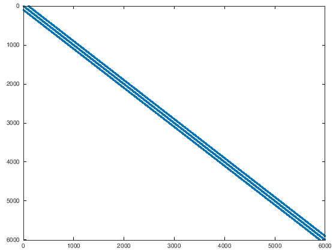

```matlab
% *** Systemmatrix fuer ortsabhaengigen Diffusionskoeffizienten ***
A_h=OrtsabhaengigeSystemmatrix(M,N,h, C_Linear);
```

## Startbedingungen

Position des Vinzentius-Krankenhaus wird festgelegt. Startpunkt für "patient zero".

```matlab
function [x, y, radius] = PositionVizentiusKrankenhausLandau (B, h)
 M = rows(B);
 N = columns(B);
 x = floor(N/2); %x-Koordinate des Krankenhaus
 y = floor(7*M/32);%y-Koordinate des Krankenhaus
 flaecheKrankenhaus = 0.02; % km^2 = 20.000 m^2 Umrechnung 10^6
 radiusKrankenhaus = sqrt(flaecheKrankenhaus/pi);
 %radius = 0.3/h; %radius von 300 Metern
 radius=radiusKrankenhaus/h;
endfunction
```

entspricht Startvektor Euler-Verfahren

```matlab
function I = InfizierteStartbedingungMatrix (B,h, StartWerte)

  M = rows(B);
  N = columns(B);
  I = zeros(M,N);
  TMP = zeros(M,N);
  %Startpositionen soll eine Matrix sein mit den Eintraegen
  %[x_1-Koordinate, y_1-Koordinate, radius_1, AnzahlInfizierte_1;
  % x_2-Koordinate, y_2-Koordinate, radius_2, AnzahlInfizierte_2;
  %      ...               ...         ...
  % x_n-Koordinate, y_n-Koordinate, radius_n, AnzahlInfizierte_n;]

  AnzahlStartPositionen = rows(StartWerte);

  for k=1:AnzahlStartPositionen

    x_Koordinate = StartWerte(k,1);
    y_Koordinate = StartWerte(k,2);
    radius = StartWerte(k,3);
    AnzahlInfizierte = StartWerte(k,4);

    for i=1:N
      for j=1:M
        if(sqrt((i.-x_Koordinate)^2+(j.-y_Koordinate)^2) <= radius)
          I(j,i) = I(j,i) + AnzahlInfizierte/(pi*radius^2);
        endif
      endfor
    endfor
  endfor
 % Normierung der Matrix, da fuer kleine Radien die Flaeche nicht Kreisfoermig ist (daher Fehler bei Flaechenberechnung)
 sollInfizierte = round(sum(I(:)));  % Da es keine nicht natuerliche Anzahl an Personen geben kann.
 istInfizierte = sum(I(:));
 quotient= sollInfizierte/istInfizierte;
 I = quotient*I/h^2;

%Plotten der Funktion
global plotten;
global speichern;

  if plotten
   figure(9995)
   global x;
   global y;
   surface (x,y,I*h^2,"EdgeColor", "none"); %stellt die absolute Anzahl der Infizierten dar durch I*h^2
   title (["Startbedingungen an Tag 0: Anzahl Infizierte: " num2str(sollInfizierte)]);
   axis([min(min(x),min(y)) max(max(x),max(y)) min(min(x),min(y)) max(max(x),max(y))])
   ylabel("y")
   xlabel("x")
   colorbar
     if speichern
      filename=["Images/Startbedingung_an_Tag_ 0_Anzahl_Infizierte" num2str(sollInfizierte) ".jpg"];
      saveas(9995, filename)
      %close (9995)
    endif
  endif

endfunction
```

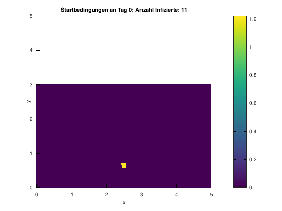

```matlab
% *** Matrix mit den Startbedingungen der Infektion ***
[x_KH,y_KH,r_KH] = PositionVizentiusKrankenhausLandau(B_Interpoliert, h);
InfizierteStartAnzahl = 10;
InfizierteStartMatrix = InfizierteStartbedingungMatrix(B_Interpoliert, h, [x_KH, y_KH, r_KH, InfizierteStartAnzahl]);
clear *_KH; %Alle Variablen die mit _KH enden werden geloescht, da nicht mehr benoetigt.
```

## Berechnung der einzelnen Tage

Beginnend mit den Anfangsbedingungen

```matlab
% *** Tag 0 ***
B = reshape(B_Interpoliert',N*M,1); %B ueberschreiben mit Vektor der interpolierten Werte; %reshape, dass Vektoren B und u_i_alt subtrahieren kann
u_i_alt = 1*reshape(InfizierteStartMatrix',N*M,1);
u_s_alt = B.-u_i_alt; %Subtraktion möglich, da aufgrund reshape von der gleichen Dimension sind
```

#### Implementation des Reaktionsterms (rechte Seite)

- ist abhängig vom aktuellen Zustand der Masse im System
- stellt den Zusammenhang der räumlichen Infektionsverbreitung als Diffusionsprozess und der Kompartimentmodelle dar

###### unbeschränktes/ logistisches Wachstum - **aktuell Infizierten** (SIR)

$f_I(\vec{u}(t)) \approx F_I(\vec{u}_h(t)):= \frac{c}{\vec{B}}*\vec{u_I}_h(t) * \vec{u_S}_h(t)-w\vec{u_I}_h(t)$  
wobei $\frac{c}{\vec{B}}$ der logistischen Infektionsrate -> Rate der Infektionsverbreitung bei einer Kontaktrate (Wahrscheinlichkeit eines Kontaktes eines Infizierten mit einem Gefährdeten) entspricht  
$w$ ist die Wechselrate von Infizierten zu den Genesenen

```matlab
function F = F_I (Erkrankungsrate, B, Wechselrate, ui, us) %hierbei ist Erkrankungsrate=slowdown(t*delta_t) * BasisErkrankungsrate
  F = (Erkrankungsrate./B);
  F(F==Inf) = 0; %Falls B an Punkten 0 ist, dann setze hier F auf 0
  F = F.*ui.*us-Wechselrate*ui;
endfunction
```

###### unbeschränktes/ logistisches Wachstum - **Gefährdeten-Susceptibles** (SIR)

$ f_S(\vec{u}(t)) \approx F_S(\vec{u}_h(t)):= -\frac{c}{\vec{B}} *\vec{u_I}_h(t) *\vec{u_S}_h(t)$

```matlab
function F = F_S (Erkrankungsrate, B, ~, ui, us)
 F = -1*(Erkrankungsrate./B);
 F(F==Inf)=0; %Falls B an Punkten 0 ist, dann setze hier F auf 0
 F = F.*ui.*us;
endfunction
```

```matlab
function val=slowdown(x)
%Nach den Angegebenen Tagen wird der angegebene Prozentsatz der urspruenglichen Rate genommen
%Prozentsatz wird durch den Faktor "val" definiert

if x<14 val=1;
%Zwischen Tag 25 (Tag der Kontaktverbote) und Tag 33 besteht Uebergangszeit
%d.h. Menschen, die sich vor den Kontaktverboten infiziert haben, werden dann erst erfasst
  elseif x<28
  val=0.4;

 elseif x<33
  val=0.3;

%Ersten 10 Tage der Kontaktverbote mit zunaechst weniger einschneidenen Maßnahmen, darueber hinaus
%haben sich nicht alle Menschen daran gehalten
  elseif x<42
  val=0.4;

%Striktere Maßnahmen zur Eindaemmung und Umdenken bei der Bevoelkerung  durch Pressemitteilungen aus Italien

  elseif x<69
  val=0.165;

%Weniger aktive Faelle und Weiterfuerhung der Beschraenkungen

elseif x<80
  val=0.09;


endif
%Beispielhafte Lockerung der Maßnahmen ab Tag 80, die die Infektionsrate wieder
%auf 50 % der Basisinfektionsrate erhoeht
%(um den Effekt der Lockerung zu beobachten)
if x>=80 val=0.5; endif
endfunction
```

### Zeitdiskretisierung der Reaktion-Diffusionsgleichung mit explizitem Eulerverfahren

- explizite Eulerverfahren ist Verfahren zur numer. Lösung eines Anfangswertproblems
- Zeitintervall $(t_0,T)$ wird in äquidistante Teilintervalle $(t_k, t_{k+1})$ der Länge $\Delta t=t_{k+1}-t_k, \quad k=0,1,\ldots K, \ T=t_0+K\Delta t$ unterteilt
- Ersetze Zeitableitung $\frac{d \vec{u}_h}{dt}$ mit dem Vorwärtsdifferenzenquotienten $D^+_{\Delta t} \vec{u}_h(t)=\frac{\vec{u}_h(t+ \Delta t)-\vec{u}_h(t)}{\Delta t}\approx \frac{d\vec{u}_h(t)}{dt}$.
- Formel: ##### \begin{eqnarray} \vec{u}_h (t_{k+1})= \vec{u}_h (t_{k}) + \Delta t \Big(-A_h\vec{u}_h (t_k)+F(\vec{u}_h (t_k))\Big), \quad k=0,1,\ldots K, \ T=t_0+K\Delta t.\end{eqnarray} mit Startvektor \begin{eqnarray} \vec{u}_h (t_0)=\vec{u}^0=(u^0 (x_0,y_0), \ldots, u^0 (x_{n+1},y_{m+1}) )^T \end{eqnarray}
- numerische Lösung im neuen Zeitschritt $\vec{u}_h (t_{k+1})$ erhält man **iterativ** durch Einsetzen der Lösung aus dem vorherigen Zeitschritt $\vec{u}_h(t_{k})$ auf der rechten Seite der obigen Formel
- **Stabilität** der numerischen Lösung: Schrittweite $\Delta t$ muss ausreichend klein gewählt werden, ansonsten kann numerische Lösung nach wenigen Schritten instabil werden und 'explodieren'
- berechneten Werte $\vec{u}_h (t_{k+1})$ stellen **Approximationen an die tatsächlichen Werte der exakten Lösung** des Anfangswert-Problems dar
- Je kleiner die Schrittweite $\Delta t$ gewählt ist, desto mehr Rechenarbeit ist nötig, aber desto genauer werden auch die approximierten Werte.

#### Berechnung aller Tage mithilfe des expliziten Euler-Verfahrens und des Reaktiondiffusions-Prozesses

In der Corona-Modellierung betrachten wir folgende Differentialgleichung (Reaktionsdiffusionsgleichung):

\begin{eqnarray} \partial_t u(x,t)-div\ (c(x)\nabla u(x,t))=f(u(x,t))\end{eqnarray}

Ersetze nun die Zeitableitung $\frac{d u_h}{dt}$ mit dem Vorwärtsdifferenzenquotienten $D^+_{\Delta t}$ und erhalte:

$\frac {u(x,t+ \Delta t)-u(x,t)}{\Delta t}-div\ (c(x)\nabla u(x,t)) = f(u(x,t)) \hspace{3cm} \mid + div\ (c(x)\nabla u(x,t)) $

$\frac {u(x,t+ \Delta t)-u(x,t)}{\Delta t} = f(u(x,t)) + div\ (c(x)\nabla u(x,t)) \hspace{3cm} \mid \cdot \Delta t$

$u(x,t+ \Delta t)-u(x,t) = {\Delta t}\cdot[f(u(x,t)) + div\ (c(x)\nabla u(x,t))] \hspace{1cm} \mid + u(x,t)$

$u(x,t+ \Delta t) = u(x,t) + {\Delta t}\cdot[f(u(x,t)) + div\ (c(x)\nabla u(x,t))] \hspace{1cm} \mid div\ (c \nabla u(x,t)) = c \cdot div(\nabla u(x,t))) = c \cdot \Delta u(x,t) $

$ u(x,t+ \Delta t) = u(x,t) + {\Delta t}\cdot[f(u(x,t)) + c \cdot \Delta u(x,t)]$

Der Ausdruck $c \cdot \Delta u(x,t)$ wird in FDM approximiert mit $ -c\Delta \vec{u}(t) \approx A_h\vec{u}_h$ . Schließlich ergibt sich die Gleichung:

##### \begin{eqnarray} u(x,t+ \Delta t) = u(x,t) + {\Delta t}\cdot[- A_h \cdot u(x,t)+f(u(x,t)) ] \end{eqnarray}

Mit dieser Formel wird die Zahl der Infizierten zum Zeitpunkt $t+\Delta t$ anhand des vorherigen Wertes zum Zeitpunkt $t$ berechnet.  
Wir betrachten **aktuell Infizierte**. Dazu muss die Wechselwirkung der Infizierten mit der Gruppe der Susceptible und der Removed betrachtet werden (Berücksichtigung der Removed im Term der Infizierten enthalten, siehe unten):  
\begin{eqnarray} \partial_t u_S(x,t)-div (c(x) \nabla u_S(x,t))=f_S(u_S(x,t), u_I(x,t)),\\ \partial_t u_I(x,t)-div (c(x) \nabla u_I(x,t))=f_I(u_S(x,t),u_I(x,t)), \end{eqnarray} wobei \begin{eqnarray}f_S(\vec{u}(t)) \approx F_S(\vec{u}_h(t)):= -\frac{c}{\vec{B}} *\vec{u_I}_h(t) *\vec{u_S}_h(t)\ (bereits\ implementiert)\\ f_I(\vec{u}(t)) \approx F_I(\vec{u}_h(t)):= \frac{c}{\vec{B}}*\vec{u_I}_h(t) * \vec{u_S}_h(t)-w\vec{u_I}_h(t)\ (bereits\ implementiert)\end{eqnarray}

```matlab
for t=1:Zeitschritte
  Erkrankungsrate = slowdown(t*delta_t) * BasisErkrankungsrate; %Änderung der BasisErkrankungsrate aufgrund der slowdown-Funktion

  u_i = u_i_alt + delta_t * (-A_h * u_i_alt + F_I(Erkrankungsrate, B, Wechselrate, u_i_alt, u_s_alt));
  u_s = u_s_alt + delta_t * (-A_h * u_s_alt + F_S(Erkrankungsrate, B, Wechselrate, u_i_alt, u_s_alt));

  u_i_alt = u_i;
  u_s_alt = u_s;

  Erkrankungsrate_Speicher(1,t)=Erkrankungsrate; %speichert aktuelle Erkrankungsrate für jeden Tag (da aufgrund von slowdwon variable)
  u_i_Speicher(:,t)=u_i;% die Lösungen der aktuell Infizierten werden zu jedem Zeitpunkt t gespeichert, sodass anschließend plottbar - da Lösung Vektoren sind hängt man Lösungsvektoren aneinander
  u_s_Speicher(:,t)=u_s;%  die Lösungen der susceptibles werden zu jedem Zeitpunkt t gespeichert, sodass anschließend plottbar
endfor
```

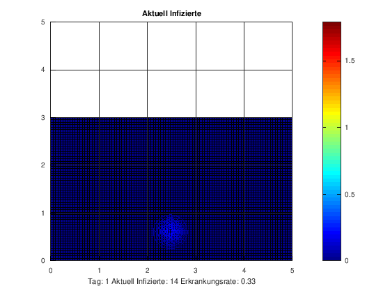

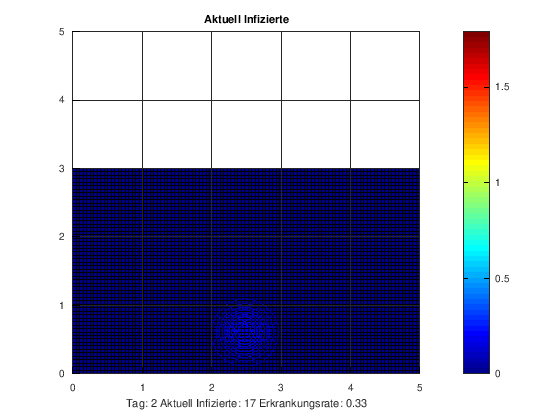

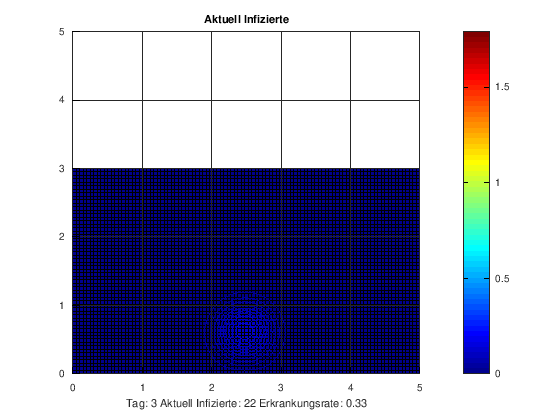

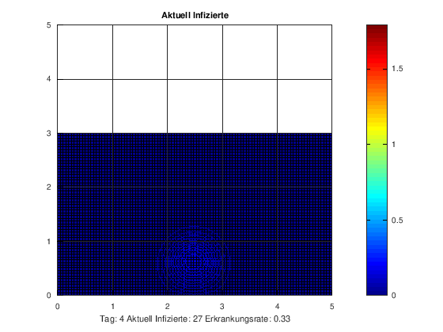

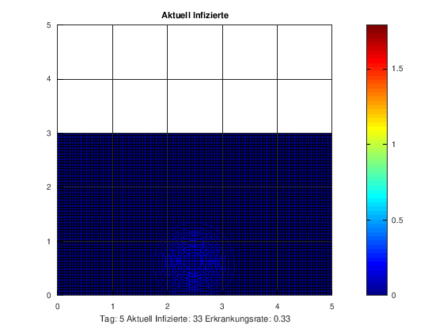

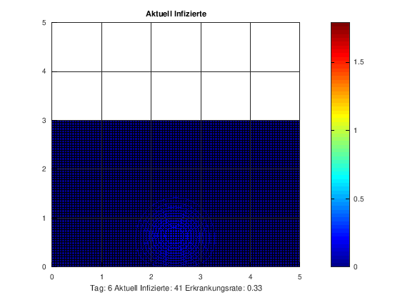

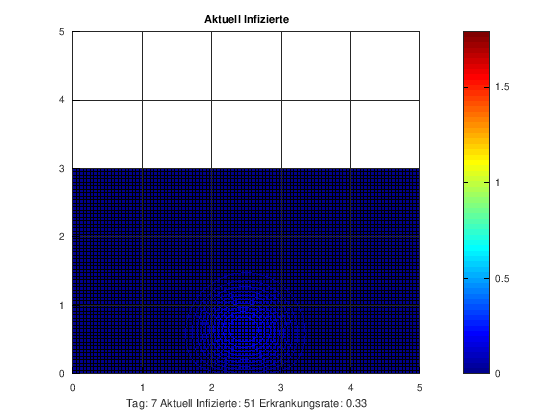

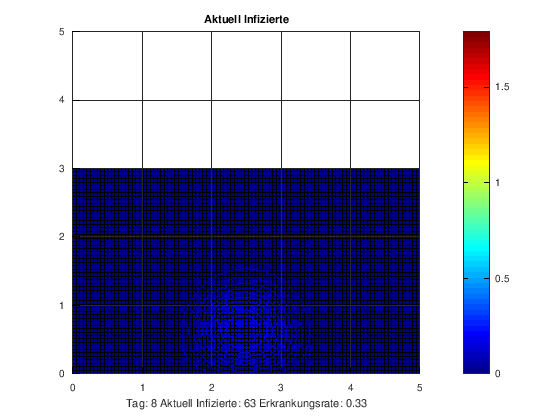

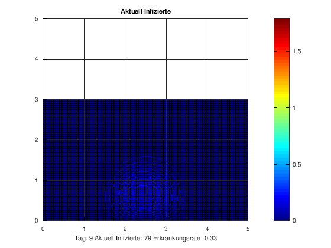

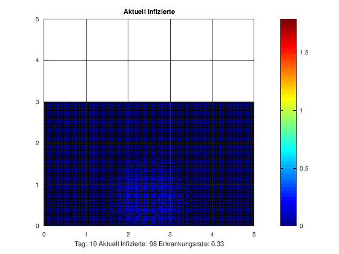

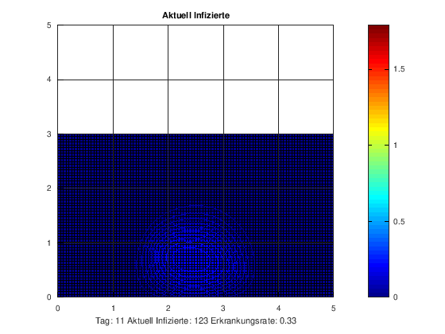

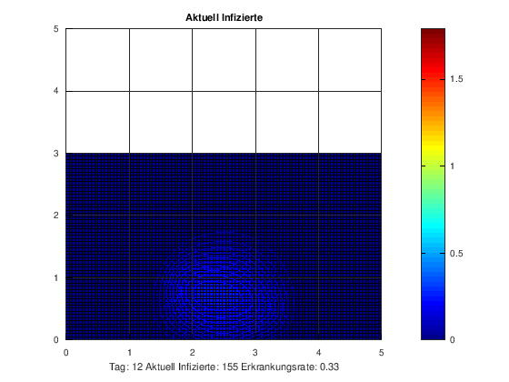

[38 more figures not shown]

```matlab
% *** Plotten der Loesungen ***
if plotten==true
fig_index=floor([1:Tage]./delta_t); %Bilder bekommen Nummern anhand von

j=0;
 for i=fig_index
  Loesung=reshape(u_i_Speicher(:,i),N,M)'; % macht aus Lösungsvektoren eine Matrix mit N(Zeilen)x M(Spalten); transponiert noch, da reshape spaltenweise funktioniert und wir zeilenweise haben wollen
  aktuell_Infizierte=sum(Loesung(:))*h^2; % summiert alle Einträge der Matrix auf; *h^2 um absolute Anzahl der Infizierten zu erhalten
  aktuell_Infizierte_Speicher(:,i*delta_t)=aktuell_Infizierte; %speichert Gesamtinfizierten der einzelnen Tage in einer Matrix
  %disp(['Figure ',num2str(i/fig_index(1))]);
  j=j+1;
  figure(j);
  %surface(Loesung*h^2, "EdgeColor", "none")
  %colormap: autumn,  hsv jet ocean
  surfc(x,y,Loesung*h^2)% *h^2 um absolute Anzahl der Infizierten zu erhalten
  view(0,90)
  colormap ("jet")
  caxis([0,max(u_i_Speicher(:))*h^2])
  axis([min(min(x),min(y)) max(max(x),max(y)) min(min(x),min(y)) max(max(x),max(y))])
  colorbar

  title (["Aktuell Infizierte"]);
  %ylabel("y")
  xlabel(["Tag: ", num2str(delta_t*i) "\tAktuell Infizierte: " num2str(floor(aktuell_Infizierte)) "\tErkrankungsrate: " num2str(Erkrankungsrate_Speicher(1,i))])
  %Optional: Speicherung der Bilder
  %hold on;
  if speichern==true
    filename=["Images/Aktuell_Infizierte_Tag_" num2str(j) "_von_" num2str(Tage) "_Raster_" num2str(M) "x" num2str(N) "_" num2str(Rasterlaenge) "m" ".jpg"];
    %saveas(j, filename)
  endif
endfor
endif
```